# Project_STA518

Cleyde Murillo, Jr., Nathanial VanDyk

10/13/2021

Setup

```r
library(tidyverse)
library(data.table)
library(readr)
library(corrr)
library(infer)
options(scipen = 999)
```

> Loading in Customer data

```r
customers <- read_tsv("marketing_campaign.csv")
summary(customers)
```

```
##        ID          Year_Birth    Education         Marital_Status
##  Min.   :    0   Min.   :1893   Length:2240        Length:2240
##  1st Qu.: 2828   1st Qu.:1959   Class :character   Class :character
##  Median : 5458   Median :1970   Mode  :character   Mode  :character
##  Mean   : 5592   Mean   :1969
##  3rd Qu.: 8428   3rd Qu.:1977
##  Max.   :11191   Max.   :1996
##
##      Income          Kidhome          Teenhome      Dt_Customer
##  Min.   :  1730   Min.   :0.0000   Min.   :0.0000   Length:2240
##  1st Qu.: 35303   1st Qu.:0.0000   1st Qu.:0.0000   Class :character
##  Median : 51382   Median :0.0000   Median :0.0000   Mode  :character
##  Mean   : 52247   Mean   :0.4442   Mean   :0.5062
##  3rd Qu.: 68522   3rd Qu.:1.0000   3rd Qu.:1.0000
##  Max.   :666666   Max.   :2.0000   Max.   :2.0000
##  NA's   :24
##     Recency         MntWines         MntFruits     MntMeatProducts
##  Min.   : 0.00   Min.   :   0.00   Min.   :  0.0   Min.   :   0.0
##  1st Qu.:24.00   1st Qu.:  23.75   1st Qu.:  1.0   1st Qu.:  16.0
##  Median :49.00   Median : 173.50   Median :  8.0   Median :  67.0
##  Mean   :49.11   Mean   : 303.94   Mean   : 26.3   Mean   : 166.9
##  3rd Qu.:74.00   3rd Qu.: 504.25   3rd Qu.: 33.0   3rd Qu.: 232.0
##  Max.   :99.00   Max.   :1493.00   Max.   :199.0   Max.   :1725.0
##
##  MntFishProducts  MntSweetProducts  MntGoldProds    NumDealsPurchases
##  Min.   :  0.00   Min.   :  0.00   Min.   :  0.00   Min.   : 0.000
##  1st Qu.:  3.00   1st Qu.:  1.00   1st Qu.:  9.00   1st Qu.: 1.000
##  Median : 12.00   Median :  8.00   Median : 24.00   Median : 2.000
##  Mean   : 37.53   Mean   : 27.06   Mean   : 44.02   Mean   : 2.325
##  3rd Qu.: 50.00   3rd Qu.: 33.00   3rd Qu.: 56.00   3rd Qu.: 3.000
##  Max.   :259.00   Max.   :263.00   Max.   :362.00   Max.   :15.000
##
##  NumWebPurchases  NumCatalogPurchases NumStorePurchases NumWebVisitsMonth
##  Min.   : 0.000   Min.   : 0.000      Min.   : 0.00     Min.   : 0.000
##  1st Qu.: 2.000   1st Qu.: 0.000      1st Qu.: 3.00     1st Qu.: 3.000
##  Median : 4.000   Median : 2.000      Median : 5.00     Median : 6.000
##  Mean   : 4.085   Mean   : 2.662      Mean   : 5.79     Mean   : 5.317
##  3rd Qu.: 6.000   3rd Qu.: 4.000      3rd Qu.: 8.00     3rd Qu.: 7.000
##  Max.   :27.000   Max.   :28.000      Max.   :13.00     Max.   :20.000
##
```

[output cut: 9 more lines]

```
##  Min.   :0.00000   Min.   :0.000000   Min.   :3     Min.   :11
##  1st Qu.:0.00000   1st Qu.:0.000000   1st Qu.:3     1st Qu.:11
##  Median :0.00000   Median :0.000000   Median :3     Median :11
##  Mean   :0.01339   Mean   :0.009375   Mean   :3     Mean   :11
##  3rd Qu.:0.00000   3rd Qu.:0.000000   3rd Qu.:3     3rd Qu.:11
##  Max.   :1.00000   Max.   :1.000000   Max.   :3     Max.   :11
##
##     Response
##  Min.   :0.0000
##  1st Qu.:0.0000
##  Median :0.0000
##  Mean   :0.1491
##  3rd Qu.:0.0000
##  Max.   :1.0000
##
```

Variable Dictionary:

`ID` = Customer’s Unique Identifier

`Year_Birth` = Customer’s birth year

`Education` = Customer’s education level

`Marital_Status` = Customer’s marital status

`Income` = Customer’s yearly household income

`Kidhome` = Number of children in customer’s household

`Teenhome:` = Number of teenagers in customer’s household

`Dt_Customer` = Date of customer’s enrollment with the company

`Recency` = Number of days since customer’s last purchase

`Complain` = 1 if customer complained in the last 2 years, 0 otherwise

`MntWines` = Amount spent on wine in last 2 years

`MntFruits` = Amount spent on fruits in last 2 years

`MntMeatProducts` = Amount spent on meat in last 2 years

`MntFishProducts` = Amount spent on fish in last 2 years

`MntSweetProducts` = Amount spent on sweets in last 2 years

`MntGoldProds` = Amount spent on gold in last 2 years

`NumDealsPurchases` = Number of purchases made with a discount

`AcceptedCmp1` = 1 if customer accepted the offer in the 1st campaign, 0 otherwise

`AcceptedCmp2` = 1 if customer accepted the offer in the 2nd campaign, 0 otherwise

`AcceptedCmp3` = 1 if customer accepted the offer in the 3rd campaign, 0 otherwise

`AcceptedCmp4` = 1 if customer accepted the offer in the 4th campaign, 0 otherwise

`AcceptedCmp5` = 1 if customer accepted the offer in the 5th campaign, 0 otherwise

`Response` = 1 if customer accepted the offer in the last campaign, 0 otherwise

`NumWebPurchases` = Number of purchases made through the company’s web site

`NumCatalogPurchases` = Number of purchases made using a catalogue

`NumStorePurchases` = Number of purchases made directly in stores

`NumWebVisitsMonth` = Number of visits to company’s web site in the last month

# Exploratory Data Analysis

```r
#Removing outliers to separate df. Very high income, NAs, irrelevant statuses and unlikely ages: total 35 observations removed
outliers <- customers %>%
        filter(Income > 200000 | is.na(Income) | Marital_Status %in% c('Absurd', 'Alone', 'YOLO') | Year_Birth < 1905)

#Removing Z_CostContact & Z_Revenue for redundancy / no value & anti-joining outliers df
customers <- customers %>%
  anti_join(outliers) %>%
  subset(select = -c(Z_CostContact, Z_Revenue))
#Creating age variable and moving to after birth year
customers <- customers %>%
  mutate(Age = as.numeric(format(Sys.Date(), '%Y')) - Year_Birth) %>%
  relocate(Age, .after = Year_Birth)
```

We will be generating visualizations (density plots, histograms, scatter plots) to understand how the data behaves

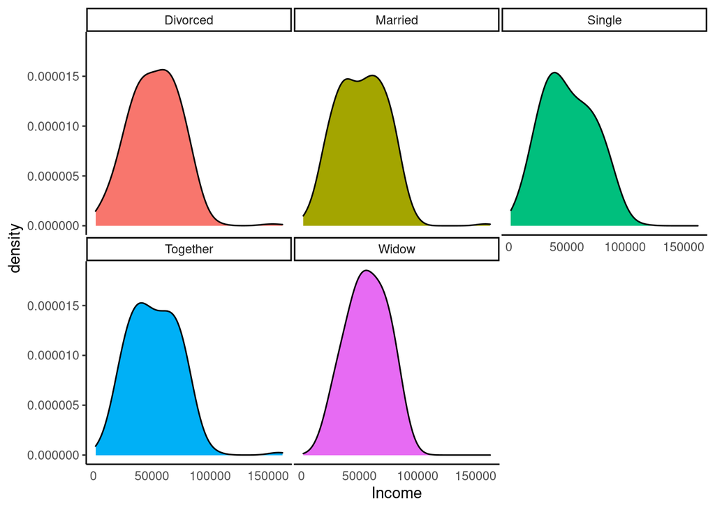

```r
ggplot(data=customers, aes(x=Income, group=Marital_Status, fill=Marital_Status)) +
    geom_density(adjust=1.5) +
    theme_classic() +
    facet_wrap(~Marital_Status) +
    theme(
      legend.position="none",
      panel.spacing = unit(0.1, "lines"),
      axis.ticks.x=element_blank()
    )
```

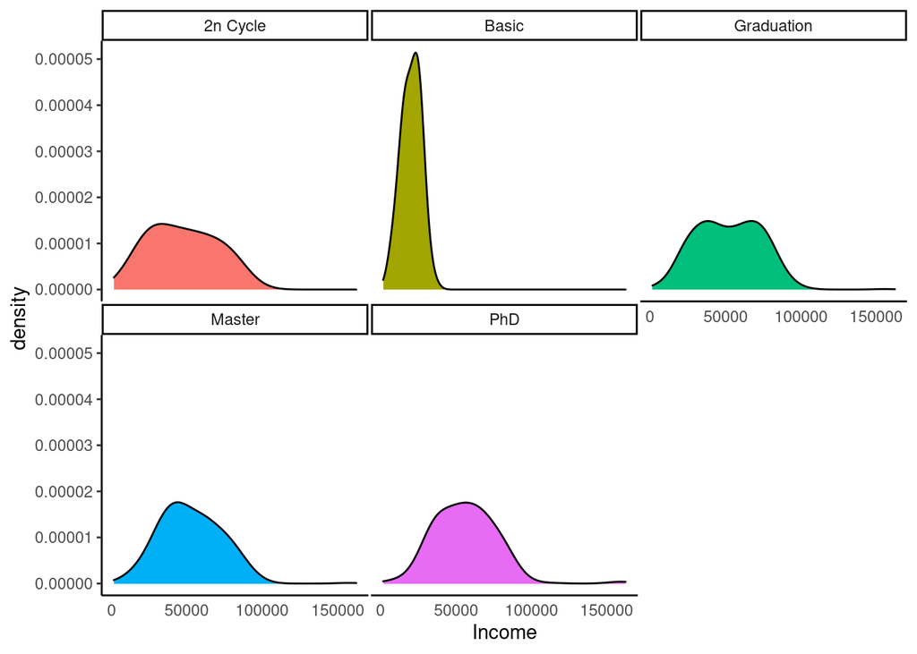

```r
ggplot(data=customers, aes(x=Income, group=Education, fill=Education)) +
    geom_density(adjust=1.5) +
    theme_classic() +
    facet_wrap(~Education) +
    theme(
      legend.position="none",
      panel.spacing = unit(0.1, "lines"),
      axis.ticks.x=element_blank()
    )
```

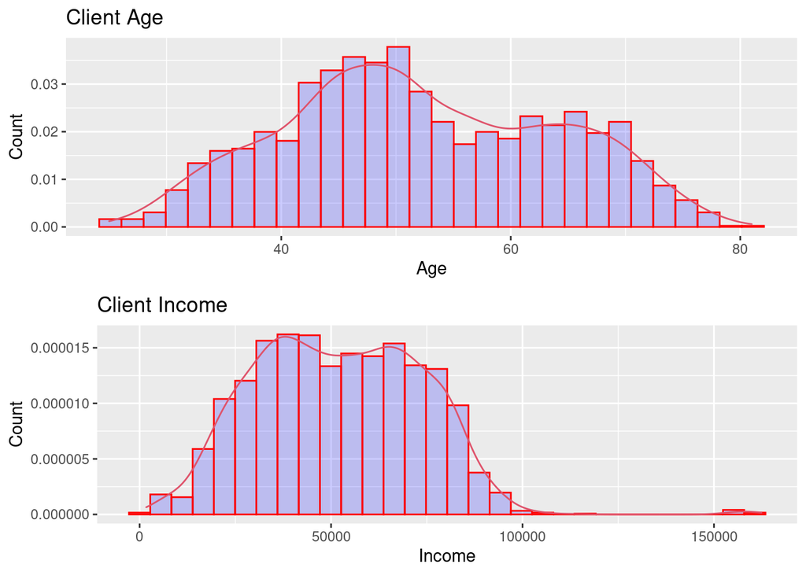

```r
p1 <- ggplot(data=customers, aes(customers$Age)) +
  geom_histogram(aes(y =..density..),
                 col="red",
                 fill="blue",
                 alpha = .2) +
  geom_density(col=2) +
  labs(title="Client Age") +
  labs(x="Age", y="Count")
p2 <- ggplot(data=customers, aes(customers$Income)) +
  geom_histogram(aes(y =..density..),
                 col="red",
                 fill="blue",
                 alpha = .2) +
  geom_density(col=2) +
  labs(title="Client Income") +
  labs(x="Income", y="Count")

gridExtra::grid.arrange(p1,p2)
```

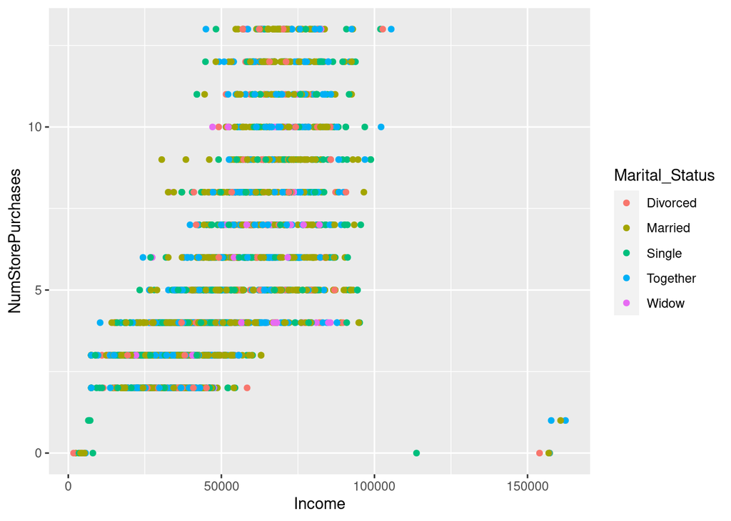

```r
ggplot(customers, aes(y=NumStorePurchases, x=Income, color=Marital_Status)) +
  geom_point()
```

```r
customer_cor <-customers %>%
  select(-ID, -Year_Birth, -Marital_Status, -Dt_Customer, -Education) %>%
  correlate()%>%
  shave()
```

```
##
## Correlation method: 'pearson'
## Missing treated using: 'pairwise.complete.obs'
```

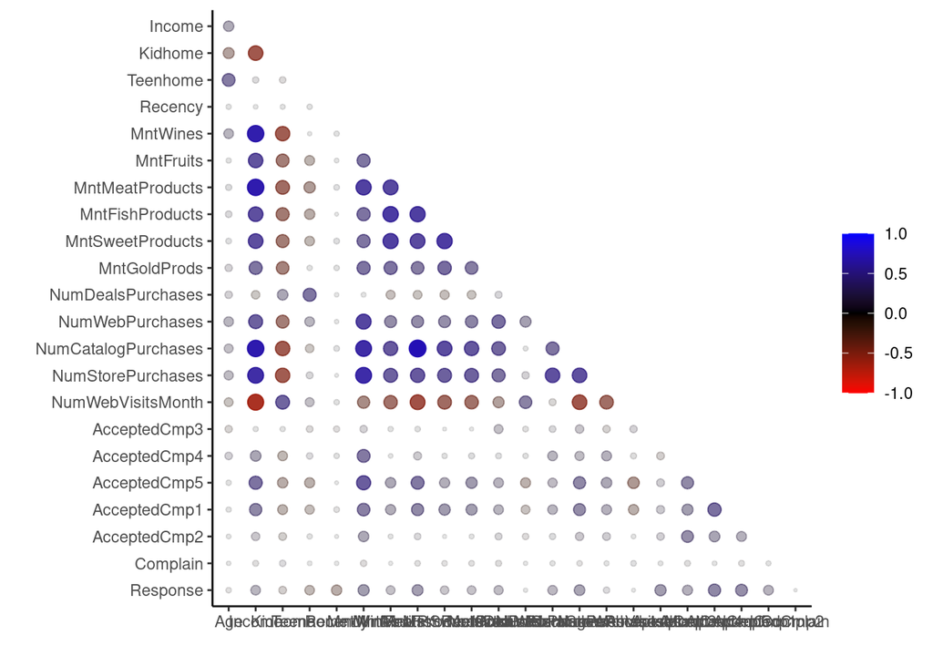

```r
rplot(customer_cor,
  shape = 20,
  colours = c("red", "black", "blue")
)
```

```r
boot_customers <- customers %>%
  rep_sample_n(size = nrow(customers),
               replace = TRUE,
               reps = 10)
```

```r
boot_customers_mean <- boot_customers %>%
                        group_by(ID) %>%
                        summarise(MeanIncome = mean(Income))
```